# Supplementary Material for “Spatially balanced sampling methods are always more precise than random ones for estimating the size of aggregated populations”

Jan Perret ([orcid](https://orcid.org/0000-0002-1912-6995)), Anne Charpentier ([orcid](https://orcid.org/0000-0002-8588-6001)), Roger Pradel ([orcid](https://orcid.org/0000-0002-2684-9251)), Guillaume Papuga ([orcid](https://orcid.org/0000-0002-7803-2219)), Aurélien Besnard ([orcid](https://orcid.org/0000-0002-2289-9761))

Created on the 2022-08-02

# Appendix S1. Comparison of the three modalities used to increase the density of the virtual populations simulated with the Matérn Cluster process

## Parameter values of the Matérn cluster process

Figure S1.1 shows the values of the three parameters of the Matérn cluster process we used to simulate the virtual populations in order to obtain the desired dispersion index levels. For modalities 1 and 3, we had to increase the cluster radius when increasing population density in order to maintain the same value of dispersion index. Thus, populations with the same dispersion index had larger clusters as density increased. In contrast, for modality 2, clusters had the same radius for the same level of dispersion index at all densities.

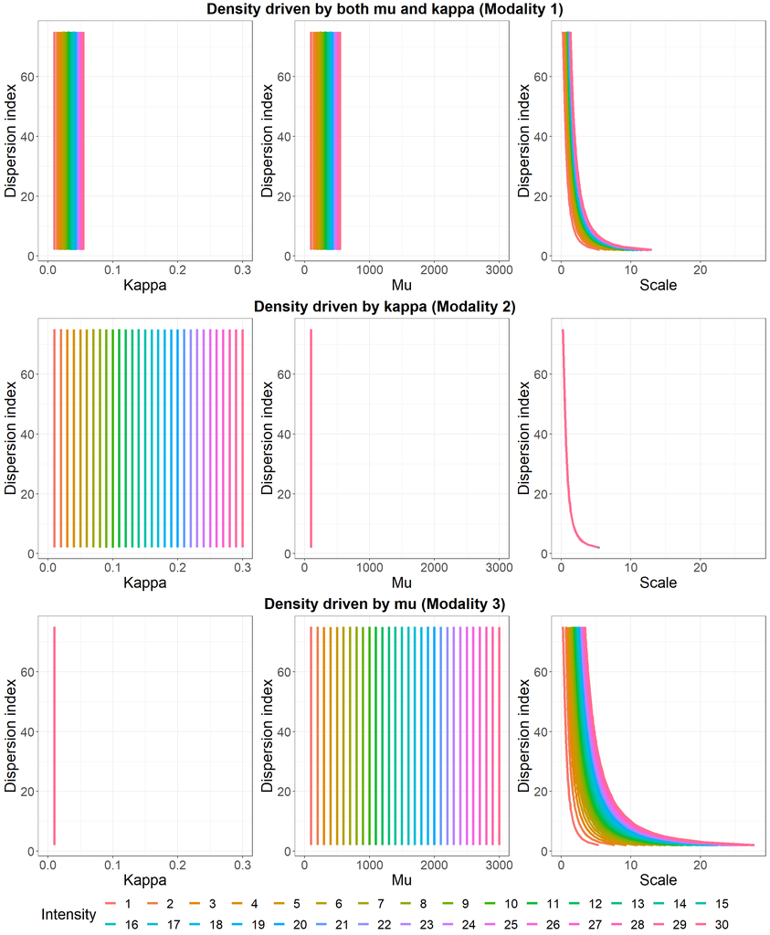

**Figure S1.1:** Parameter values of the Matérn cluster process used to obtain the desired dispersion index levels under the three possible modalities for increasing the mean density of the virtual populations. The three parameters were the mean density of clusters (kappa), the mean number of individuals per cluster (mu), and the cluster radius (scale).

## Variance ratio as a function of the dispersion index

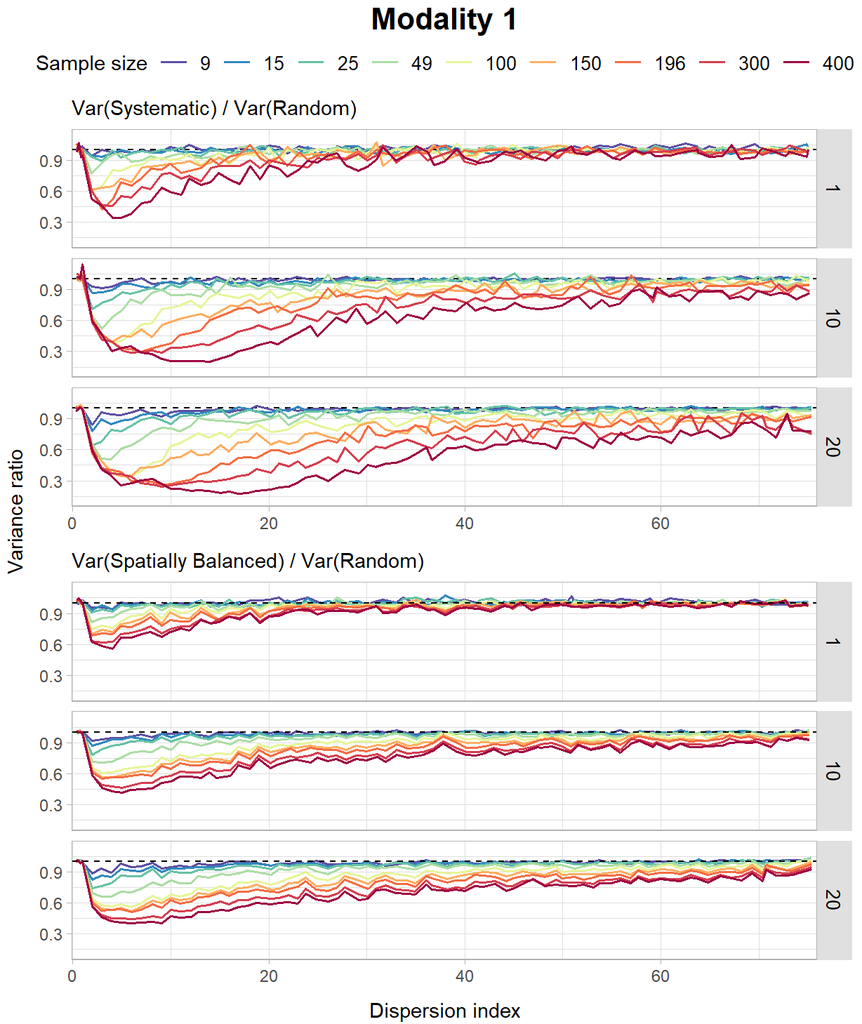

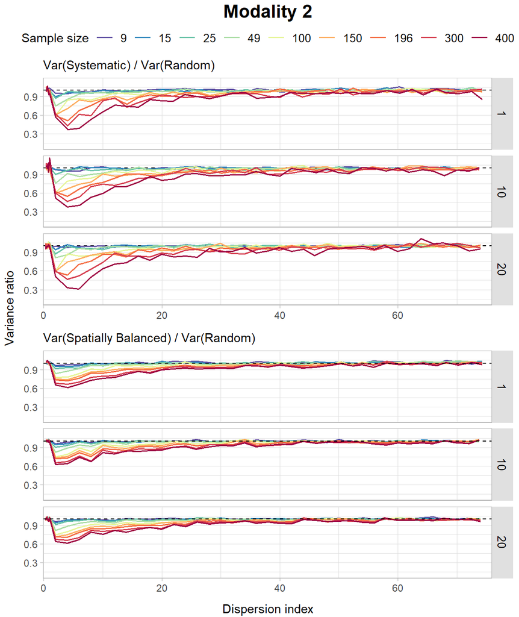

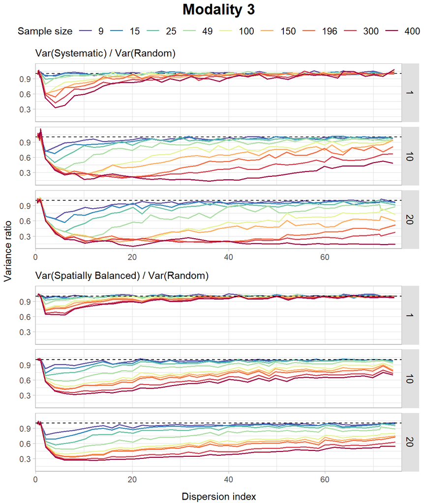

**Figure S1.2:** Ratio of the sampling variance of systematic sampling (SYS) and spatially balanced sampling (SBS) over the sampling variance of simple random sampling (SRS), as a function of the dispersion index (I) of the sampled populations. Panels show three different mean densities of individuals (1, 10 and 20 individuals/cell). For the aggregated populations, density was increased by increasing either both kappa and mu (modality 1), only kappa (modality 2) or only mu (modality 3). Each point of the curves is the ratio of two sampling variances estimated from 1,000 samples drawn for 60 populations.

## SYS variance ratio as a function of cluster diameter

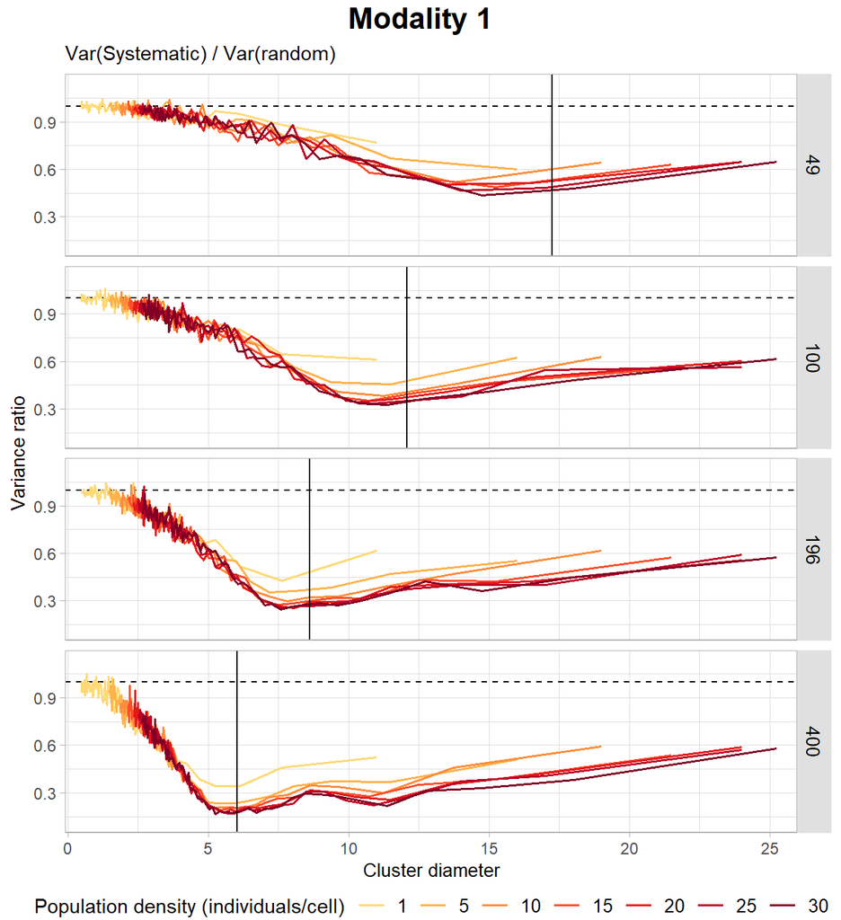

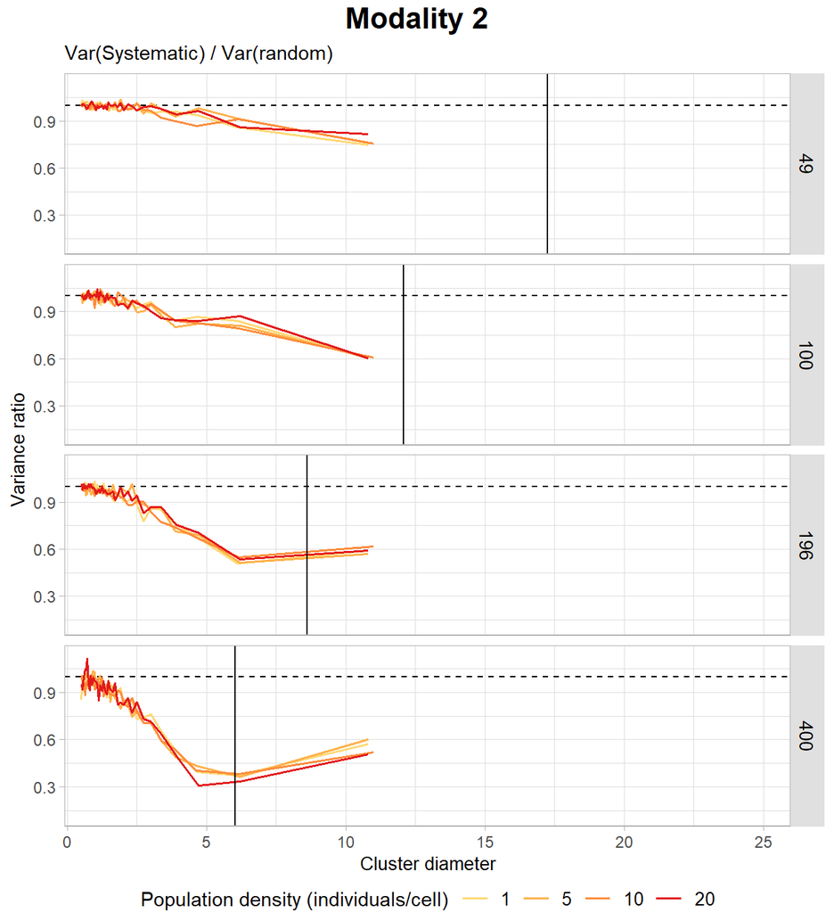

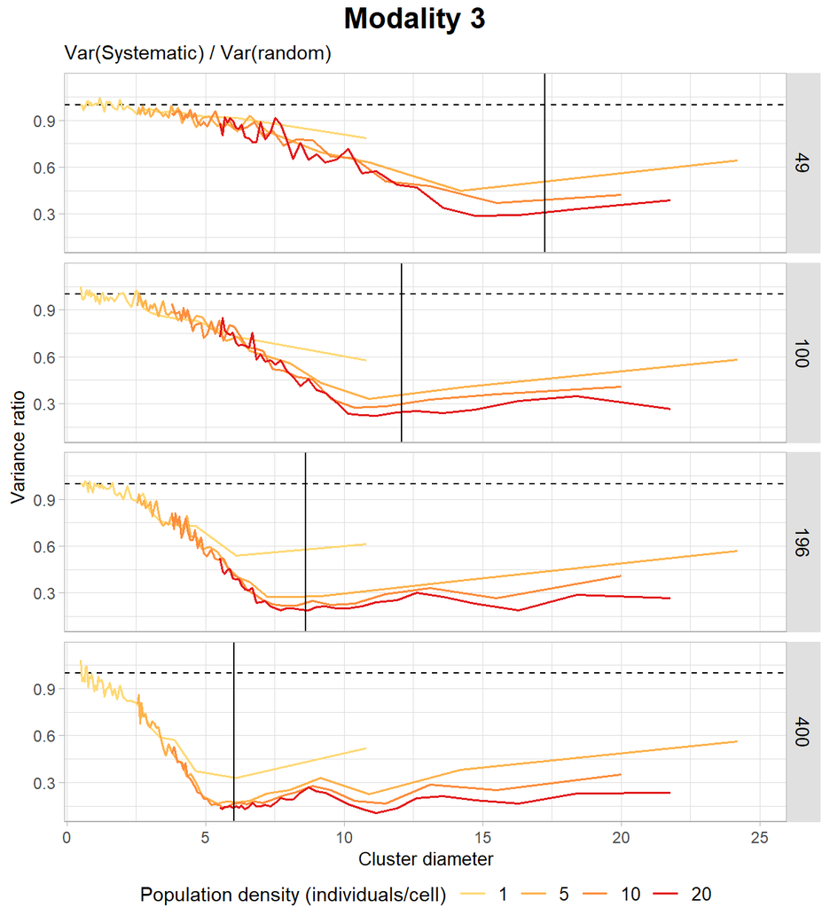

**Figure S1.3:** Ratio of the sampling variance of systematic sampling (SYS) over the sampling variance of simple random sampling (SRS) for the aggregated populations. The x-axis is the cluster diameter, and panels show four different sample sizes. Each curve shows the variance ratio obtained for a different mean density of individuals. The black vertical lines show the point where the distance between the sampling units is equal to the cluster diameter. Density was increased by increasing either both kappa and mu (modality 1), only kappa (modality 2) or only mu (modality 3).

## SBS variance ratio as a function of cluster diameter

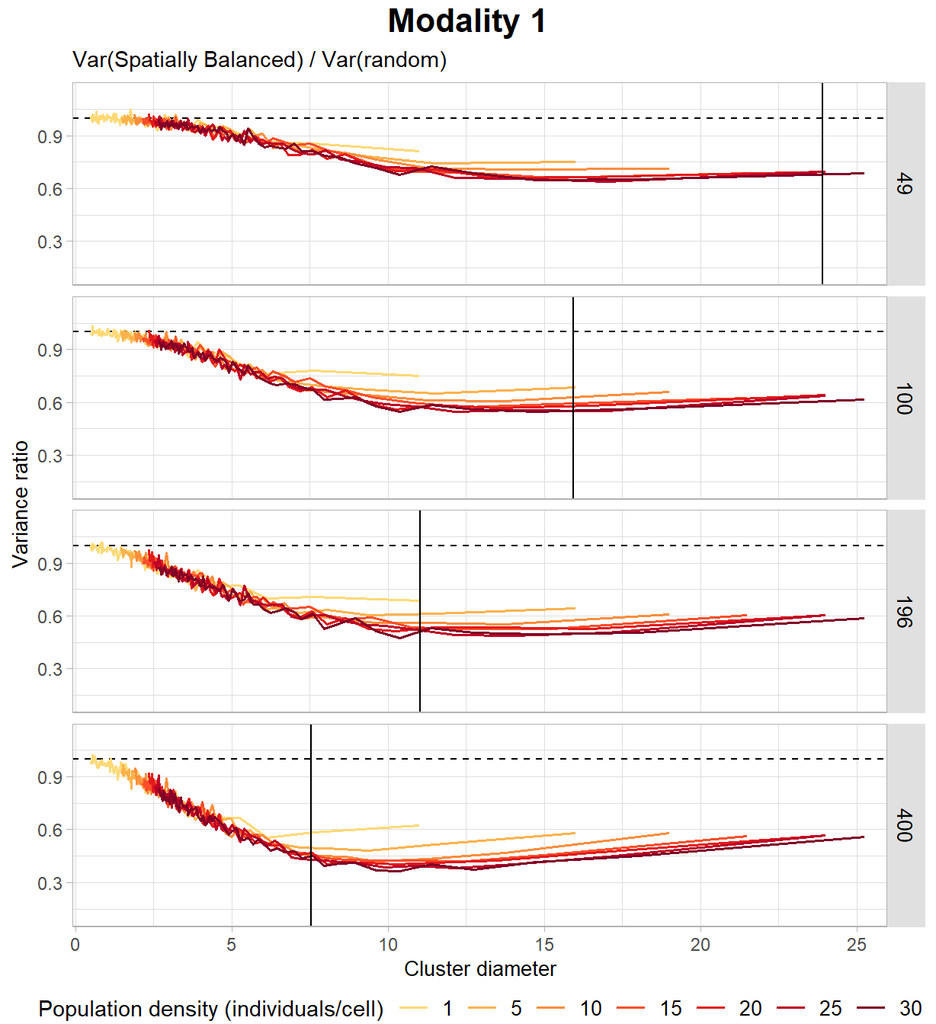

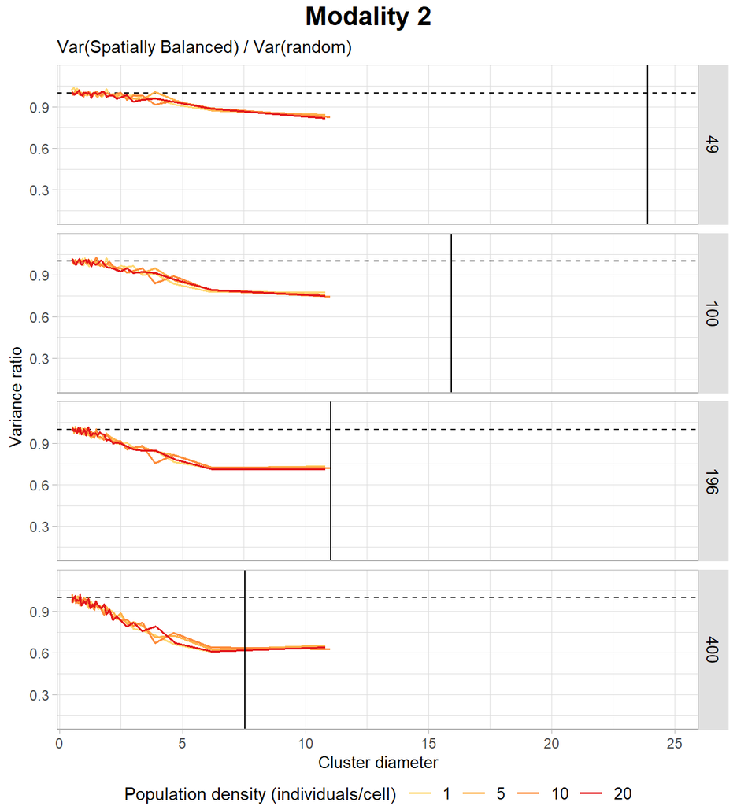

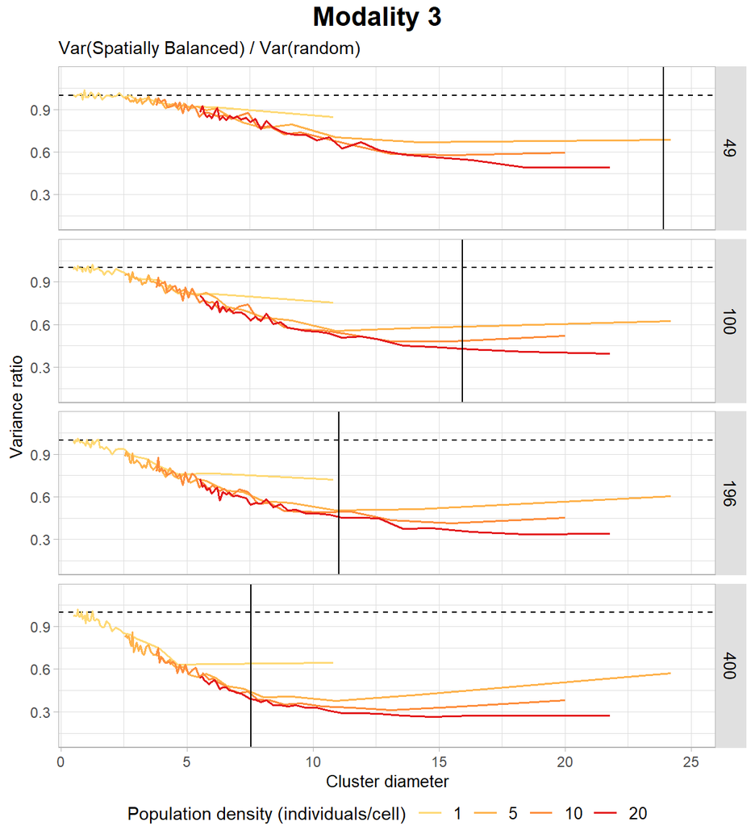

**Figure S1.4:** Ratio of the sampling variance of spatially balanced sampling (SBS) over the sampling variance of simple random sampling (SRS) for the aggregated populations. The x-axis is the cluster diameter, and panels show four different sample sizes. Each curve shows the variance ratio obtained for a different mean density of individuals. The black vertical lines show the point where the mean distance to the twelve nearest sampling units is equal to the cluster diameter. Density was increased by increasing either both kappa and mu (modality 1), only kappa (modality 2) or only mu (modality 3).

# Appendix S2. Examples of simulated virtual populations

The examples of the simulated virtual populations are in the file “Appendix_S2_pattern_illustration.zip”. For the populations simulated using the SSI process, examples are presented for mean densities of 1, 10 and 20 individuals/cell, and levels of dispersion index I = 0.4, 0.6 and 0.8. For the populations simulated using the Matérn cluster process, examples are presented for mean densities of 1, 5, 10, 15, 20, 25 and 30 individuals/cell, and levels of dispersion index of I = 6, 15, 30, 45 and 75. Examples of population are presented for the three density increase modalities. For populations simulated with the Poisson process (I = 1), examples are presented on the same page as the populations simulated with the Matérn cluster process. For the three point processes, the same parameter values were used as for the simulations presented in the main text, but the simulation window was reduced to 25x25 (instead of 100x100) for illustrative purposes. A histogram showing the number of individuals per 1x1 cell is associated to each virtual population.

# Appendix S3. Verification of lack of bias in the density estimates

For all populations, both virtual and natural, whatever the sample size, the mean density estimates resulting from the three sampling methods were always very close to the true population density. The difference between the estimated density and the true density was usually less than 0.1 individual/cell, and sometimes less than 0.01 individual/cell. This indicates that all sampling methods provided unbiased estimates, regardless of the density of the studied population, its aggregation level and the sample size used. This result was expected from sampling theory, as for the three sampling methods the sample mean is a design-unbiased estimator of the population mean, meaning that the estimates will be unbiased whatever the characteristics of the studied population (Thompson, 2012). Figure S3.1 shows the difference between the true population density and the estimated population density for the virtual populations and sampling designs presented in Figure 2 of the main text. Similar results were found for all densities we simulated, and for the three modalities used to increase population density with the Matérn cluster process.

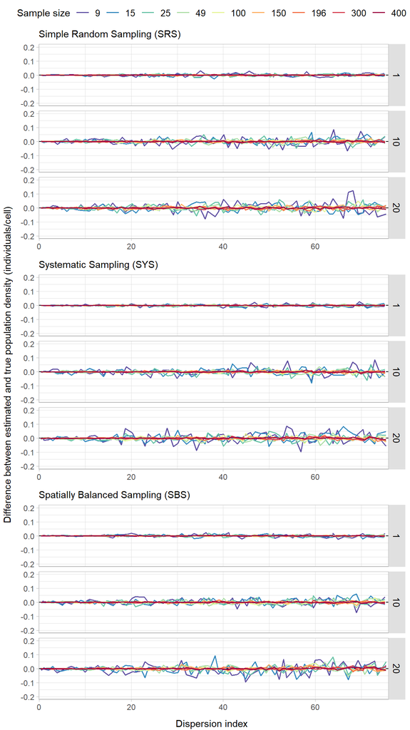

**Figure S3.1:** Difference between the true population density and the estimated population density obtained with simple random sampling (SRS), systematic sampling (SYS) and spatially balanced sampling (SBS), as a function of the dispersion index (I) of the sampled populations. Panels show three different mean densities of individuals (1, 10 and 20 individuals/cell). For the aggregated populations, density was increased by simultaneously increasing the number of clusters and the number of individuals per cluster (modality 1). Each point of the curves was obtained by computing the average over 60 populations of the difference between the true density and the mean of 1,000 sample means.

# Appendix S4. Test of variance estimators

In the main text of the paper we have shown that on average SYS and SBS provide more precise or at least as precise population size estimates as SRS for aggregated populations. However, a main difficulty when using SYS (and to a lesser extent for SBS) is to obtain an accurate variance estimate from a single sample, to have a reliable estimate of the uncertainty associated to the population size estimate. We therefore assessed the performance of multiple variance estimators that have shown promising results in recent studies, and proposed an additional estimator (V_ZIP) that is more adapted for populations following the Matern cluster process we used to simulate our virtual populations. Our goal was to check if the gain in precision of the population size estimates we have shown is not lost because of poor variance estimators available for SYS and SBS. We performed these tests on both the virtual and the three natural populations we studied.

**Take home message:** As expected, for the virtual populations, the variance estimators we selected from previous studies for SYS overestimated sampling variance when the distance between the sampling units was close to the mean cluster diameter. Conversely, our estimator V_ZIP was almost unbiased under these conditions, but it underestimated variance for higher aggregation levels. For SBS, the most commonly used estimator in the literature (V_nbh) had relatively good performances. For the natural populations using SYS or SBS, both some estimators from previous studies and our V_ZIP estimator performed well, yielding almost unbiased estimates of sampling variance. Overall, using SYS or SBS instead of SRS with a variance estimator that is appropriate for the studied population will generally result in a substantial gain in ‘apparent’ precision, although this gain will usually be slightly smaller than the gain in true precision.

## Methods

The variance estimators we selected for this study are presented in Table S4.1. For SBS, a single estimator (V_nbh) was identified as the best performing in all studies (e.g. Grafstrom et al., 2012; Robertson et al., 2013). For SYS, we chose the best performing estimators among the 16 that have been tested in three recent studies (McGarvey et al., 2016; Magnussen & Fehrmann, 2019; Magnussen et al., 2020).

All these estimators are based on the same principle: compute the sample variance and a correlation metric of the abundance among neighbouring sample units; use the correlation metric to weight the sample variance. Several correlation metrics (e.g. Moran’s I for V_w, Geary’s C for V_str2) and several definitions of the neighbourhood (e.g. the 4 closest units, all units within a given radius) are possible, but apart from that, the principle remains the same. Thus, these estimators are relevant only when there is correlation of abundance among neighbouring units in the sample.

Yet for our virtual populations simulated using a Matern process, when sampling with SYS (and to a lesser extent SBS), for sample sizes for which the distance between the sampling units is equal to the diameter of the clusters (allowing the largest gain in precision compared to SRS), there is no correlation between the neighbouring units included in the sample. Indeed, under these conditions, there can only be one sample unit per cluster, and as the position of the clusters is random, whether a unit is in a cluster or not is independent of whether its neighbouring units are in a cluster or not. Therefore, the estimators using the correlation between neighbouring units in the sample will considerably overestimate the sampling variance under these conditions. In addition, the individuals inside clusters are randomly located, i.e. following a Poisson process. We have therefore proposed a new variance estimator that is better adapted to populations where individuals are grouped in well-defined clusters.

Our new estimator is based on the hypothesis that sampling a population where individuals are grouped into well-defined clusters and where there are no individuals outside these clusters using SYS or SBS is equivalent to randomly drawing a sample in a Zero-Inflated Poisson distribution (ZIP). Indeed, the sampling units in the clusters approximately follow a Poisson distribution, and the sampling units outside the clusters constitute an excess of zeros with respect to this Poisson distribution. The computation of our estimator (called V_ZIP) is performed in three steps:

1. Estimate the two parameters of the ZIP distribution (lambda, the expected mean of the Poisson distribution, and pi, the probability of extra zeros) from the sample by maximum likelihood (Beckett et al., 2014; Jackman et al., 2020).
2. Compute the population variance estimate using lambda and pi using the following formula : S_hat^2 = lambda * (1 - pi) * (1 + pi * lambda)
3. Compute the sampling variance estimate from the population variance based on the hypothesis that the sample was drawn randomly: v_ZIP = (S_hat^2 / n) * (1 - n/N)

**Table S4.1:** Summary of the variance estimators we tested.

| Notation | Sampling method | Source | Performance tests | Why we choose it |
| --- | --- | --- | --- | --- |
| V_textbook | SRS, SYS and SBS | Cochran (1977) eq. (2.20) p. 26 | McGarvey et al. (2016) ; Magnussen & Fehrmann (2019) ; Magnussen et al. (2020) | Used as benchmark in all papers studying the performance of variance estimators. |
| V_8 | SYS | Wolter (2007) eq. (8.2.9) p. 302 | McGarvey et al. (2016) | One of the two best performing estimators among the 13 tested in McGarvey et al. (2016). |
| V_w | SYS | D'Orazio (2003) table 2 & eq. (4.3) p. 284 & 285 | McGarvey et al. (2016) | One of the two best performing estimators among the 13 tested in McGarvey et al. (2016). |
| V_str2 | SYS | D'Orazio (2003) eq. (4.1) and (4.2) p. 285 | Magnussen & Fehrmann (2019) ; Magnussen et al. (2020) | One of the two best performing estimators among the five tested in Magnussen et al. (2020) that did not show a tendency to underestimate variance. |
| V_nbh | SBS | Stevens & Olsen (2003) | Grafstrom et al. (2012) ; Robertson et al. (2013) | The best performing estimator in Grafstrom et al. (2012) and Robertson et al. (2013). |
| V_ZIP | SYS and SBS |  |  | The variance estimator we propose, better adapted to populations following a Matern cluster process than the other estimators which are based on the correlation between neighbouring sampling units. |

To evaluate the performance of these estimators, we ran the same simulations as for the main text of the article for both the virtual and natural populations, and for each simulated sampling survey, we computed the variance estimated from the sample with each estimator, and computed the associated 95% confidence interval.

To save computation time, for the virtual populations we kept only one level of dispersion index out of two, we ran the simulations for 20 populations instead of 60 for each combination of density and aggregation, and realised 600 sampling surveys per population instead of 1,000. For SYS, some of the estimators we selected are not applicable when the units cannot be arranged in a square grid, so we removed the sample sizes of n = 15, 150 and 300.

For both virtual and natural populations, we present below the following results:  
1. The ratio of the estimated variance (averaged over all the sampling surveys) using each estimator over the true sampling variance to check whether the variance estimates are **biased or not**.  
2. The **coverage ratio** obtained with each estimator, which is the proportion of sampling survey simulations for which the true mean density of individuals was within the 95% confidence interval (CI) of the density of individuals estimated using a given variance estimator.  
3. The ratio of the variance estimated using each variance estimator for SYS and SBS over the variance estimated using the “textbook” estimator for SRS, to show in which situations using SYS or SBS instead of SRS will allow for an **“apparent” gain** in precision.

## 1. Virtual populations

### 1.1 Comparison of estimated variance and true variance

In this section, we compare the mean variance estimates obtained with the variance estimators to the true sampling variances. Only the mean variance estimate is used and there is no measure of estimate precision. Thus, the figures below only allow to assess the average lack of bias of the variance estimators and not their precision. For the assessment of the variance estimate precision, see the next section about the estimator coverage ratio.

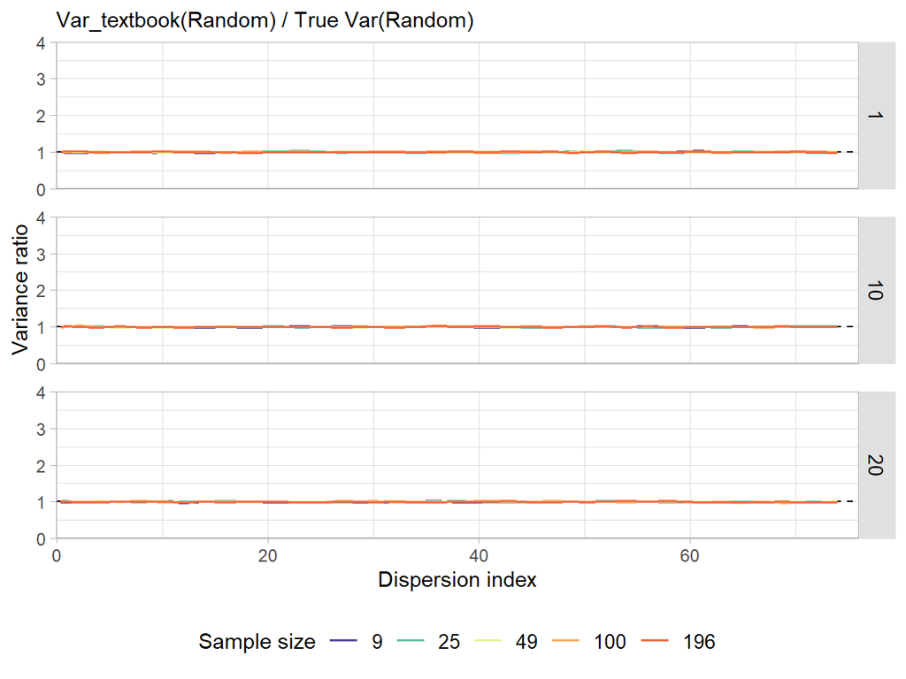

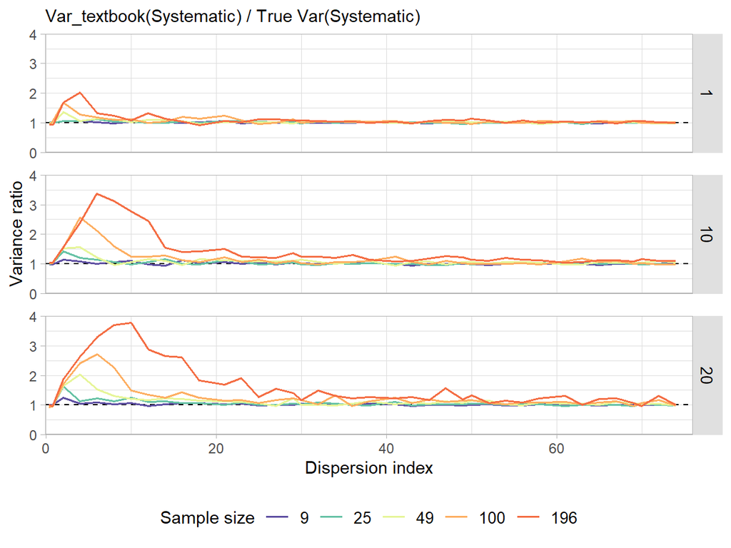

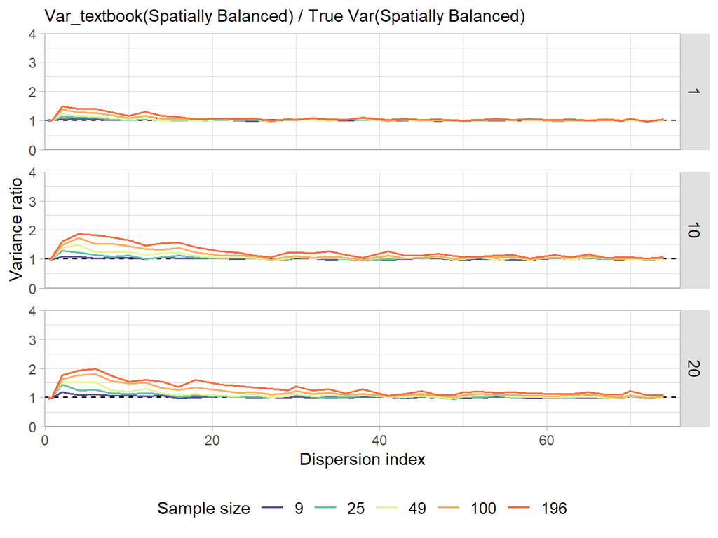

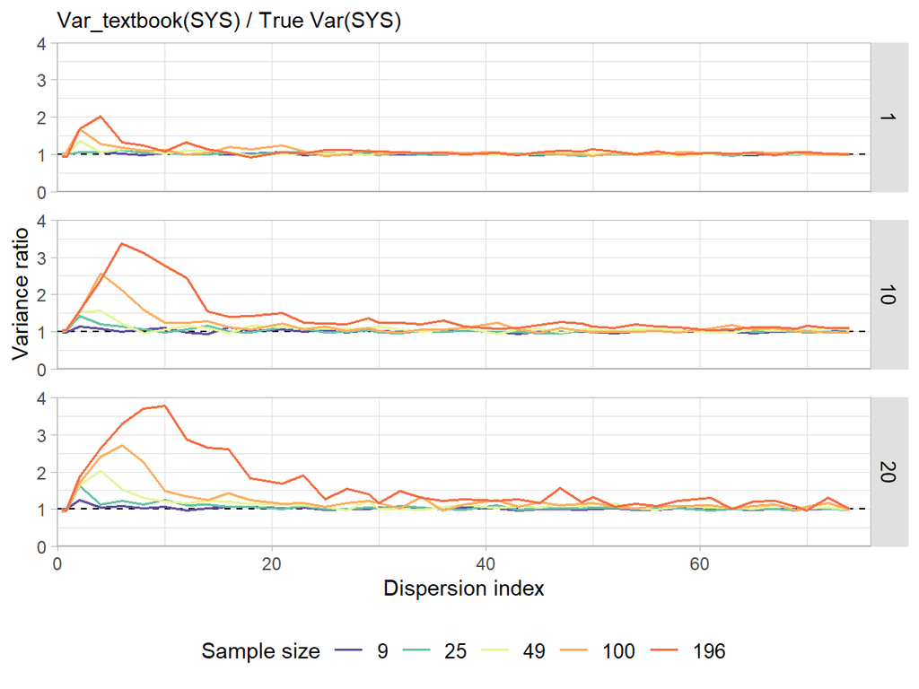

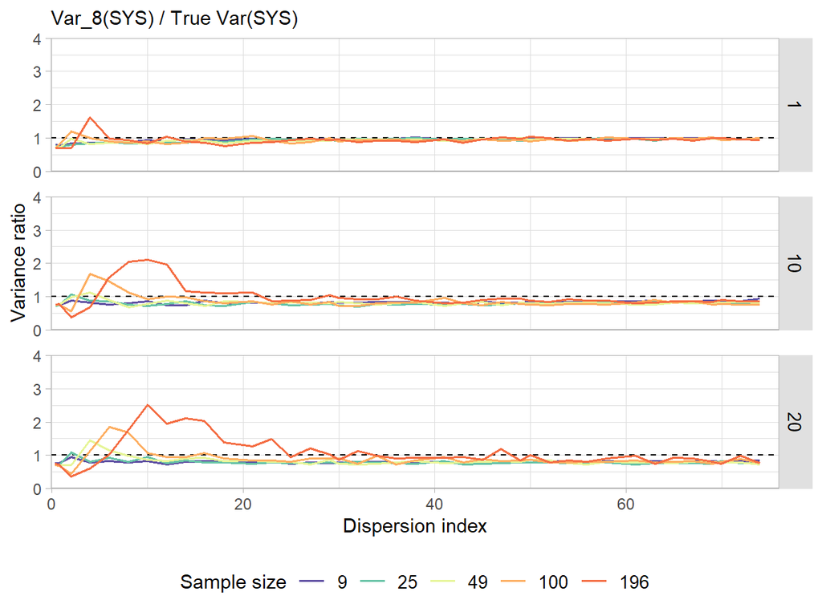

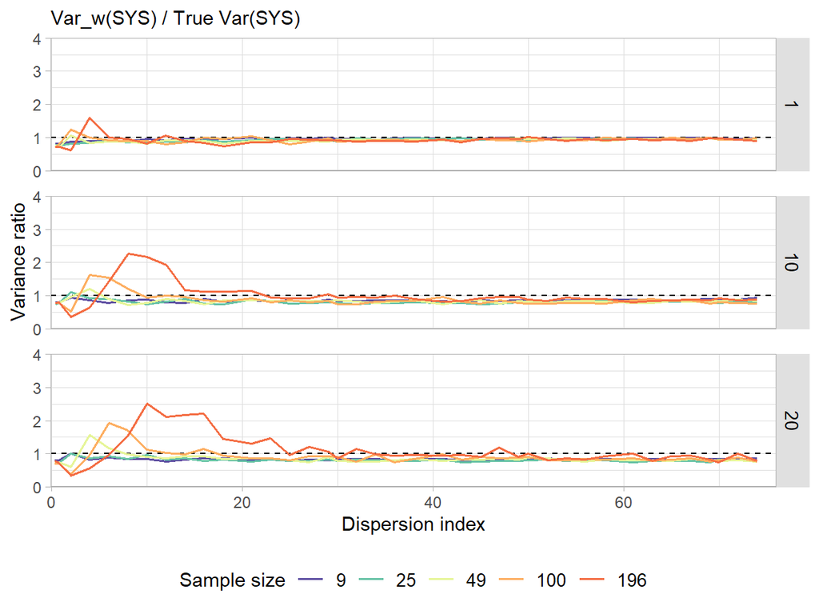

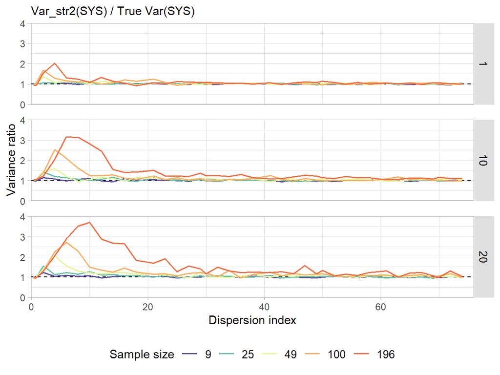

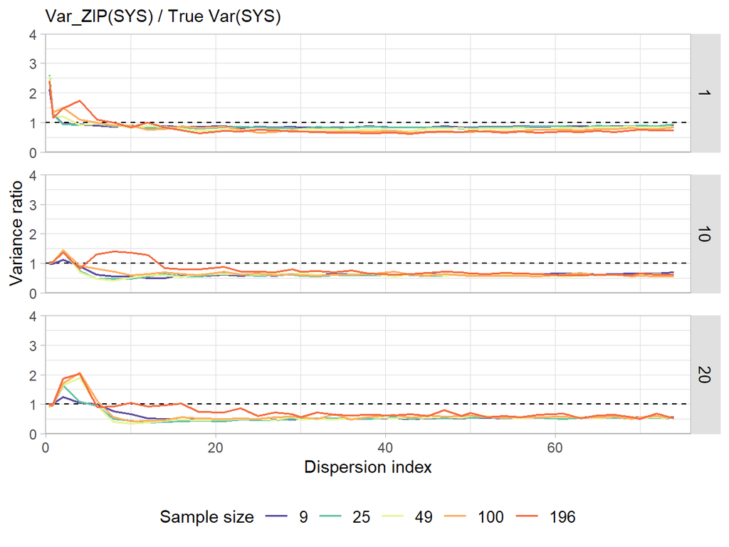

**Figure S4.2:** Ratio of the estimated sampling variance using five variance estimators (V_textbook, V_8, V_w, V_str2, V_ZIP) over the true sampling variance for systematic sampling (SYS), as a function of the dispersion index (I) of the sampled populations. Panels show three different mean densities of individuals (1, 10 and 20 individuals/cell).

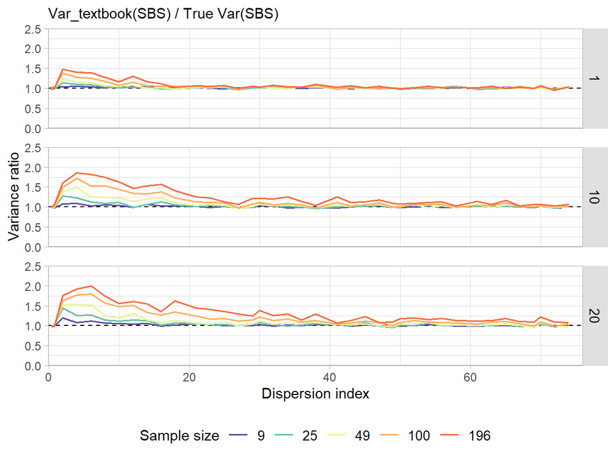

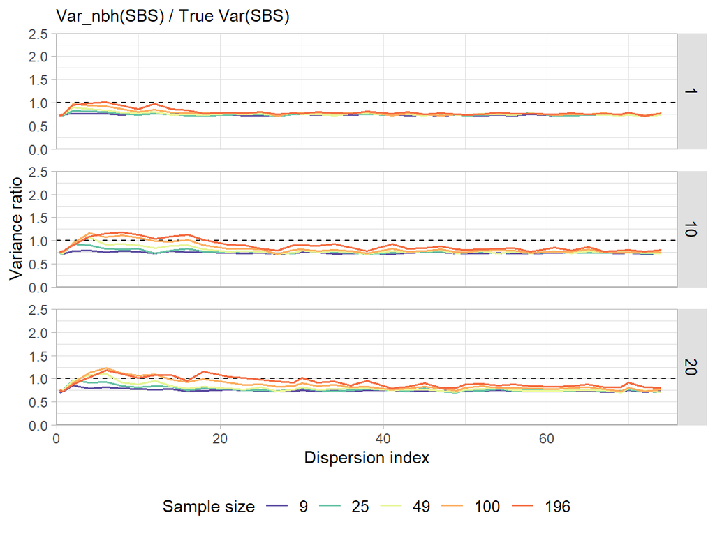

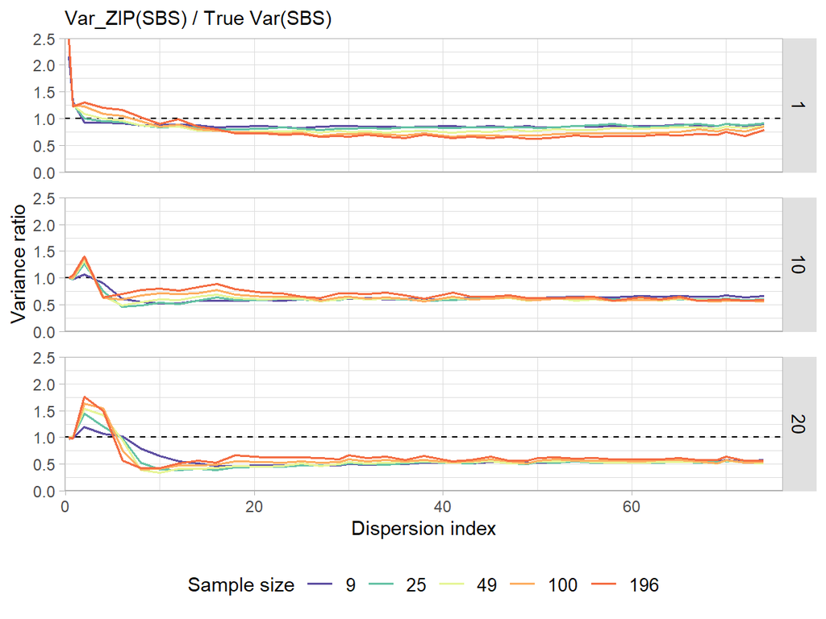

**Figure S4.3:** Ratio of the estimated sampling variance using three variance estimators (V_textbook, V_nbh and V_ZIP) over the true sampling variance for spatially balanced sampling (SYS), as a function of the dispersion index (I) of the sampled populations. Panels show three different mean densities of individuals (1, 10 and 20 individuals/cell).

### 1.2 Estimator coverage ratio

In this section, we present the coverage ratio yielded by each variance estimator. The coverage ratio is defined as the proportion of sampling survey simulations for which the true mean density of individuals was within the 95% confidence interval (CI) of the density of individuals estimated using a given variance estimator.

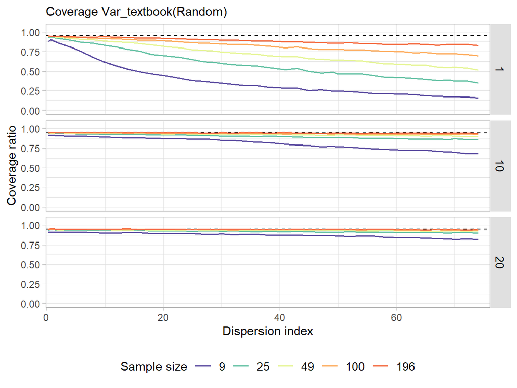

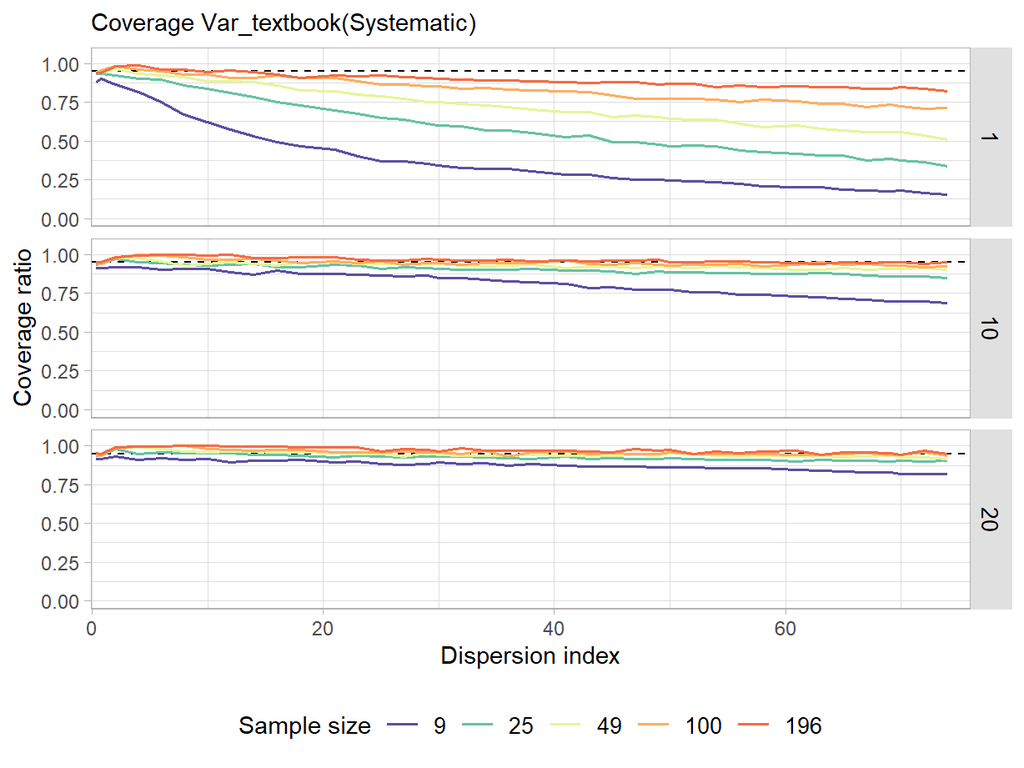

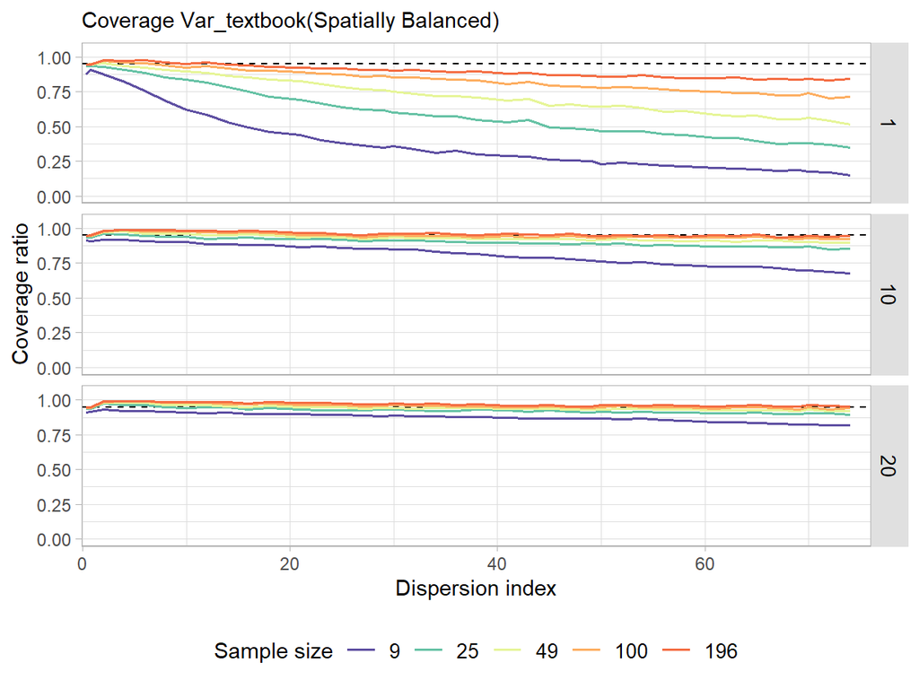

**Figure S4.4:** Coverage ratio of the “textbook” estimator for simple random sampling (SRS), systematic sampling (SYS) and spatially balanced sampling (SBS), as a function of the dispersion index (I) of the sampled populations. Panels show three different mean densities of individuals (1, 10 and 20 individuals/cell).

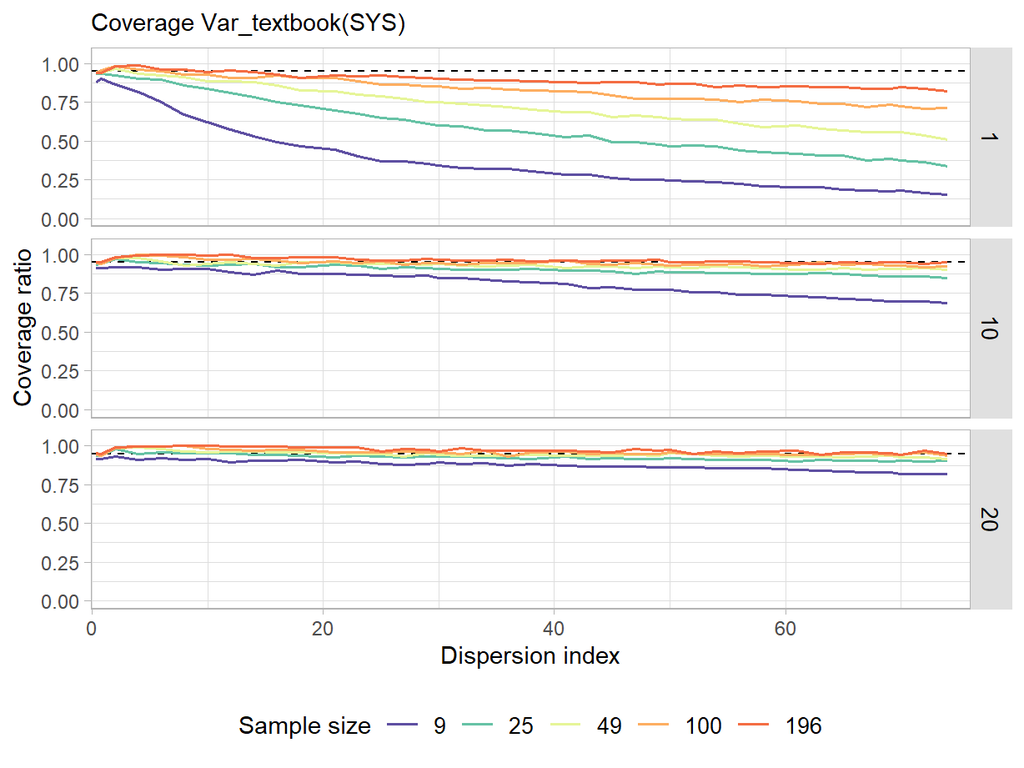

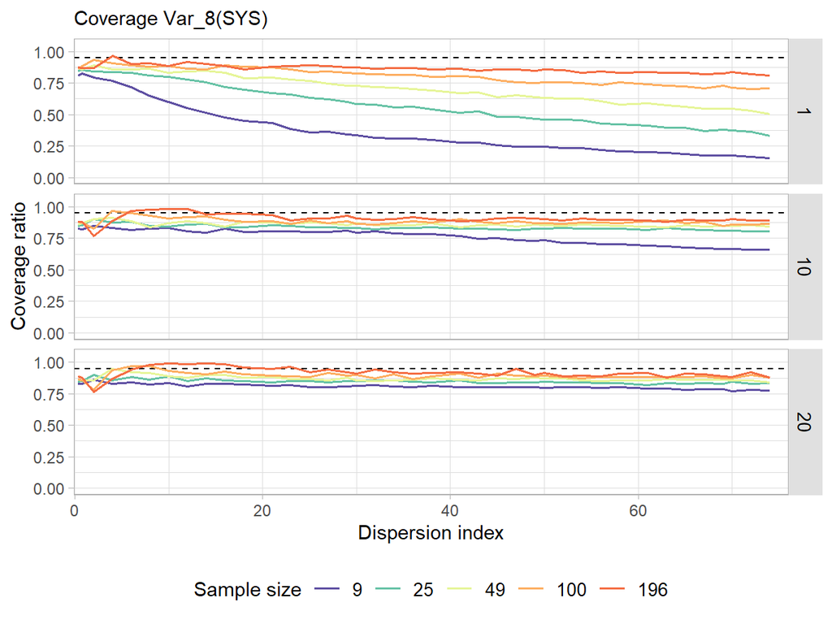

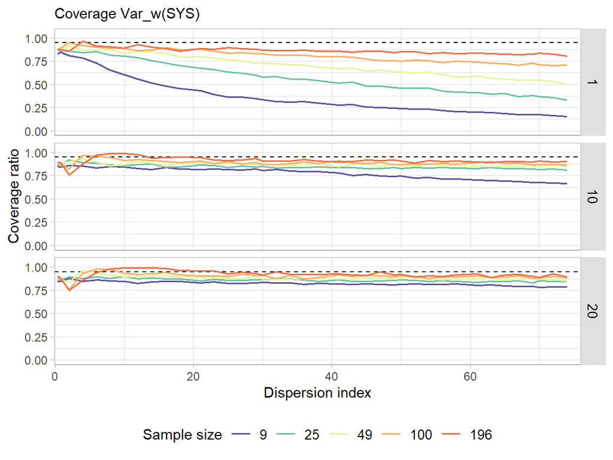

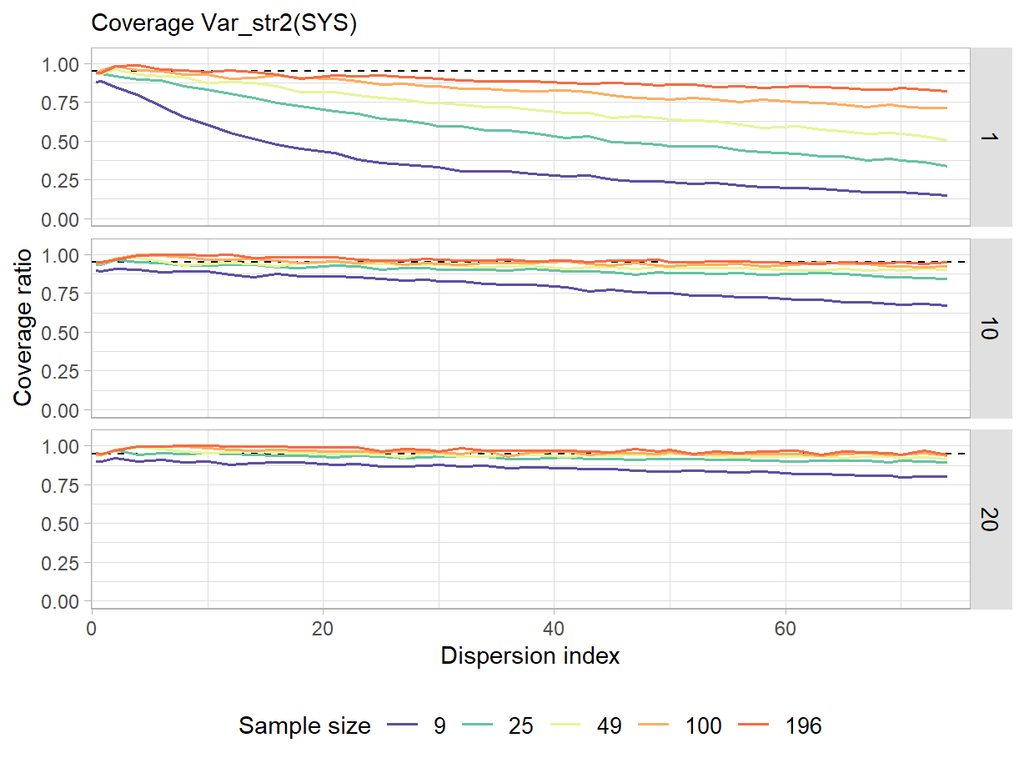